# Mathematical Models from Gleick’s Chaos: Making a New Science

Extracted for Computational Modeling Project

2026-01-20

# Overview

This document extracts and implements the key mathematical models from James Gleick’s “Chaos: Making a New Science” (1987). These models form the foundation of chaos theory and nonlinear dynamics, with profound implications for psychology, cognitive science, and complex systems.

# 1. The Lorenz System (The Butterfly Effect)

## Background

Edward Lorenz discovered deterministic chaos in 1963 while studying atmospheric convection. His simplified weather model revealed that tiny differences in initial conditions lead to vastly different outcomes - the “Butterfly Effect.”

## The Equations

The Lorenz system consists of three coupled differential equations:

$$\begin{aligned}
\frac{dx}{dt} &= \sigma(y - x) \\
\frac{dy}{dt} &= x(\rho - z) - y \\
\frac{dz}{dt} &= xy - \beta z
\end{aligned}$$

**Classic Parameters (from the book):** - $\sigma = 10$ (Prandtl number) - $\rho = 28$ (Rayleigh number) - $\beta = 8/3$ (geometric factor)

**As written in the book:**

```
dx/dt = 10(y-x)
dy/dt = –xz + 28x – y
dz/dt = xy–(8/3)z
```

## Implementation in R

```r
# Define the Lorenz system
lorenz <- function(t, state, parameters) {
  with(as.list(c(state, parameters)), {
    # Equations
    dx <- sigma * (y - x)
    dy <- x * (rho - z) - y
    dz <- x * y - beta * z

    # Return derivatives
    list(c(dx, dy, dz))
  })
}

# Classic parameters
parameters <- c(sigma = 10, rho = 28, beta = 8/3)

# Initial conditions (slightly perturbed for butterfly effect demonstration)
initial_state1 <- c(x = 1, y = 1, z = 1)
initial_state2 <- c(x = 1.001, y = 1, z = 1)  # Tiny difference!

# Time sequence
times <- seq(0, 50, by = 0.01)

# Solve the system for both initial conditions
out1 <- ode(y = initial_state1, times = times, func = lorenz, parms = parameters)
out2 <- ode(y = initial_state2, times = times, func = lorenz, parms = parameters)

# Convert to dataframe
lorenz_df1 <- as.data.frame(out1) %>% mutate(trajectory = "Initial 1")
lorenz_df2 <- as.data.frame(out2) %>% mutate(trajectory = "Initial 2")
lorenz_df <- bind_rows(lorenz_df1, lorenz_df2)
```

### Visualization: The Lorenz Attractor

```r
# Create 3D plot
plot_ly(lorenz_df1, x = ~x, y = ~y, z = ~z,
        type = 'scatter3d', mode = 'lines',
        line = list(width = 2, color = ~time, colorscale = 'Viridis')) %>%
  layout(title = "The Lorenz Attractor (Butterfly Effect)",
         scene = list(
           xaxis = list(title = "X"),
           yaxis = list(title = "Y"),
           zaxis = list(title = "Z")
         ))
```

[interactive chart not shown]

### Butterfly Effect Demonstration

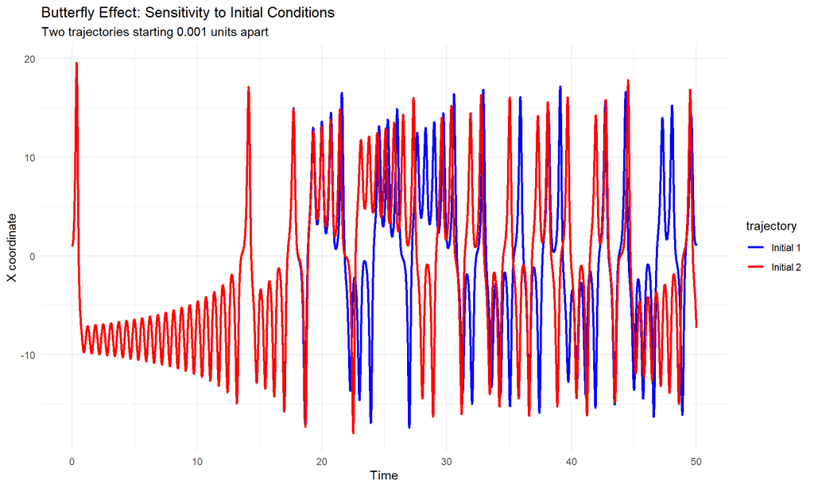

```r
# Show divergence of trajectories over time
ggplot(lorenz_df, aes(x = time, y = x, color = trajectory)) +
  geom_line(linewidth = 1) +
  labs(title = "Butterfly Effect: Sensitivity to Initial Conditions",
       subtitle = "Two trajectories starting 0.001 units apart",
       x = "Time", y = "X coordinate") +
  theme_minimal() +
  scale_color_manual(values = c("blue", "red"))
```

# 2. The Logistic Map (Population Dynamics)

## Background

Robert May studied this equation in the context of population biology. Despite its simplicity, it exhibits incredibly complex behavior including period-doubling bifurcations and chaos.

## The Equation

$$x_{n+1} = rx_n(1 - x_n)$$

where: - $x_n$ is the population at generation $n$ (expressed as a fraction between 0 and 1) - $r$ is the growth rate parameter

**Behavior depends on $r$:** - $r < 1$: Population dies out - $1 < r < 3$: Population stabilizes - $3 < r < 3.57$: Period-doubling bifurcations (2, 4, 8, 16… year cycles) - $r > 3.57$: Chaos

## Implementation in R

```r
# Logistic map function
logistic_map <- function(r, x0, n_iterations = 100) {
  x <- numeric(n_iterations)
  x[1] <- x0

  for (i in 2:n_iterations) {
    x[i] <- r * x[i-1] * (1 - x[i-1])
  }

  return(x)
}

# Example: Different values of r
r_values <- c(2.7, 3.2, 3.5, 3.8)
x0 <- 0.5

logistic_results <- map_df(r_values, function(r) {
  x_vals <- logistic_map(r, x0, n_iterations = 100)
  tibble(
    r = r,
    iteration = 1:100,
    x = x_vals
  )
})
```

### Visualization: Population Dynamics

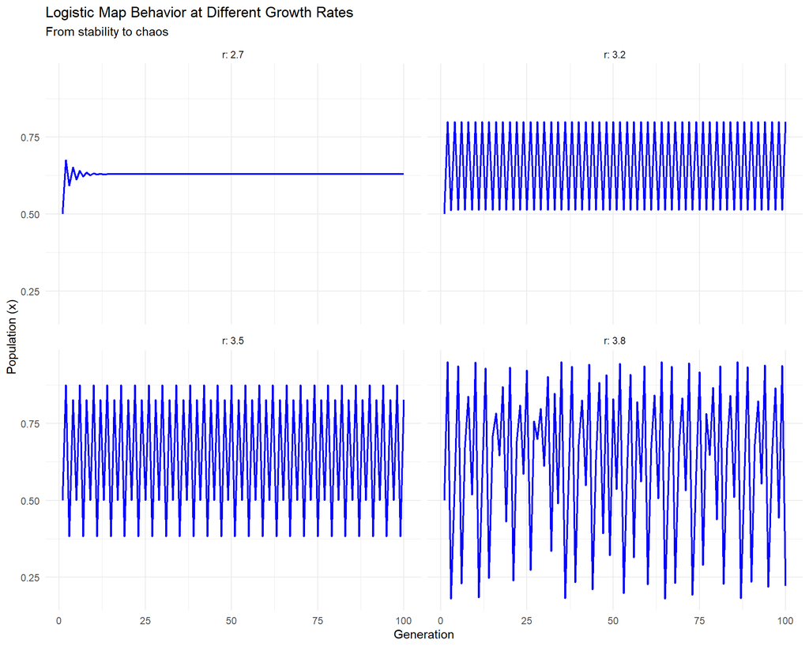

```r
ggplot(logistic_results, aes(x = iteration, y = x)) +
  geom_line(color = "blue", linewidth = 0.8) +
  facet_wrap(~r, labeller = label_both, ncol = 2) +
  labs(title = "Logistic Map Behavior at Different Growth Rates",
       subtitle = "From stability to chaos",
       x = "Generation", y = "Population (x)") +
  theme_minimal()
```

# 3. Bifurcation Diagram & Feigenbaum Constants

## Background

Mitchell Feigenbaum discovered universal constants in the period-doubling route to chaos. These constants appear in ALL systems that undergo period-doubling bifurcations, regardless of the specific equations.

## Feigenbaum Constants

**δ (delta) ≈ 4.6692016090…** - The rate at which bifurcations occur - Each bifurcation happens δ times faster than the previous one

**α (alpha) ≈ 2.502907875…** - Describes the scaling of parameter space

## Implementation: Bifurcation Diagram

```r
# Function to compute bifurcation diagram
bifurcation_data <- function(r_range, x0 = 0.5, n_iterations = 500, n_last = 200) {

  results <- tibble()

  for (r in r_range) {
    x <- logistic_map(r, x0, n_iterations)
    # Keep only last n_last points (after transients die out)
    x_stable <- x[(n_iterations - n_last + 1):n_iterations]

    results <- bind_rows(results,
                        tibble(r = r, x = x_stable))
  }

  return(results)
}

# Generate bifurcation diagram data
r_sequence <- seq(2.5, 4.0, by = 0.002)
bifurcation_df <- bifurcation_data(r_sequence)
```

### Visualization: The Bifurcation Diagram

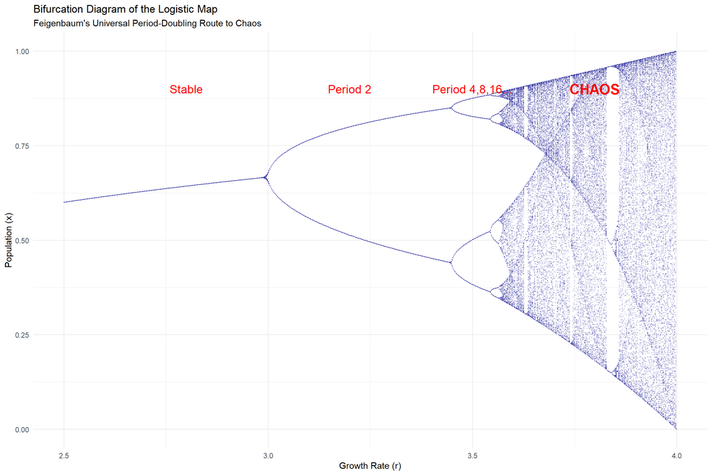

```r
ggplot(bifurcation_df, aes(x = r, y = x)) +
  geom_point(size = 0.1, alpha = 0.3, color = "darkblue") +
  labs(title = "Bifurcation Diagram of the Logistic Map",
       subtitle = "Feigenbaum's Universal Period-Doubling Route to Chaos",
       x = "Growth Rate (r)",
       y = "Population (x)") +
  annotate("text", x = 2.8, y = 0.9, label = "Stable", color = "red", size = 5) +
  annotate("text", x = 3.2, y = 0.9, label = "Period 2", color = "red", size = 5) +
  annotate("text", x = 3.5, y = 0.9, label = "Period 4,8,16...", color = "red", size = 5) +
  annotate("text", x = 3.8, y = 0.9, label = "CHAOS", color = "red", size = 6, fontface = "bold") +
  theme_minimal()
```

# 4. Strange Attractors

## Background

Strange attractors are geometric structures in phase space that represent the long-term behavior of chaotic systems. They have fractal properties and infinite complexity.

## Properties:

1. **Sensitive dependence on initial conditions**
2. **Bounded behavior** (doesn’t fly off to infinity)
3. **Fractal structure** (self-similar at all scales)
4. **Deterministic** (follows exact rules, yet unpredictable)

The Lorenz attractor (shown above) is the most famous strange attractor.

# 5. Cognitive Science Applications

## Why This Matters for Psychology

1. **Neural Dynamics**: Brain activity exhibits chaotic patterns
2. **Decision Making**: Small perturbations in initial conditions → large behavioral differences
3. **Learning & Memory**: Attractors represent stable mental states
4. **Perception**: Multistable perception involves switching between attractors
5. **Behavioral Patterns**: Habit formation and automaticity as attractors

## Potential Research Questions

- How do motivation systems create strange attractors in goal pursuit?
- Can automaticity be modeled as convergence to an attractor?
- Do implicit theories create basin boundaries between different behavioral patterns?
- How does reinforcement learning navigate chaotic state spaces?

# 6. Advanced Visualizations

## Animated Lorenz Attractor

```r
# Create animated version
lorenz_anim <- ggplot(lorenz_df1[1:1000,], aes(x = x, y = z)) +
  geom_path(color = "blue", alpha = 0.6) +
  geom_point(size = 3, color = "red") +
  transition_reveal(time) +
  labs(title = "Lorenz Attractor Evolution",
       subtitle = "Time: {frame_along}",
       x = "X", y = "Z") +
  theme_minimal()

# Save animation
anim_save("lorenz_attractor.gif", lorenz_anim,
          width = 800, height = 600, fps = 30, duration = 10)
```

## Phase Space Portraits

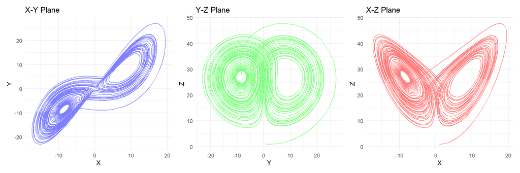

```r
p1 <- ggplot(lorenz_df1, aes(x = x, y = y)) +
  geom_path(color = "blue", alpha = 0.5) +
  labs(title = "X-Y Plane", x = "X", y = "Y") +
  theme_minimal()

p2 <- ggplot(lorenz_df1, aes(x = y, y = z)) +
  geom_path(color = "green", alpha = 0.5) +
  labs(title = "Y-Z Plane", x = "Y", y = "Z") +
  theme_minimal()

p3 <- ggplot(lorenz_df1, aes(x = x, y = z)) +
  geom_path(color = "red", alpha = 0.5) +
  labs(title = "X-Z Plane", x = "X", y = "Z") +
  theme_minimal()

library(patchwork)
p1 + p2 + p3
```

# 7. Python Integration for Advanced Rendering

```r
# This chunk shows how to integrate Python for 3D rendering
library(reticulate)

# Python code for advanced visualization
py_code <- '
import numpy as np
import matplotlib.pyplot as plt
from mpl_toolkits.mplot3d import Axes3D
from scipy.integrate import odeint

def lorenz(state, t, sigma=10, rho=28, beta=8/3):
    x, y, z = state
    dx = sigma * (y - x)
    dy = x * (rho - z) - y
    dz = x * y - beta * z
    return [dx, dy, dz]

# Integrate
t = np.linspace(0, 50, 10000)
initial = [1, 1, 1]
states = odeint(lorenz, initial, t)

# 3D Plot
fig = plt.figure(figsize=(12, 9))
ax = fig.add_subplot(111, projection="3d")
ax.plot(states[:, 0], states[:, 1], states[:, 2], lw=0.5)
ax.set_xlabel("X")
ax.set_ylabel("Y")
ax.set_zlabel("Z")
ax.set_title("Lorenz Attractor - Python/Matplotlib")
plt.savefig("lorenz_python.png", dpi=300)
'

# Execute Python code
# py_run_string(py_code)
```

# Summary

This document has extracted and implemented the core mathematical models from Gleick’s “Chaos”:

1. **Lorenz System** - Weather model that revealed deterministic chaos
2. **Logistic Map** - Simple population model with complex behavior
3. **Bifurcation Diagrams** - Visual representation of period-doubling
4. **Feigenbaum Constants** - Universal numbers in chaos (δ ≈ 4.669, α ≈ 2.503)
5. **Strange Attractors** - Geometric structures representing chaotic dynamics

## Next Steps for Your Project

1. **Extend to other attractors**: Rössler, Hénon, etc.
2. **Fractal geometry**: Implement Mandelbrot and Julia sets
3. **Real data applications**: Apply to behavioral/neural data
4. **Interactive dashboards**: Create Shiny apps for parameter exploration
5. **Publication-quality figures**: Export high-res versions for presentations

# References

- Gleick, J. (1987). *Chaos: Making a New Science*. Viking Penguin.
- Lorenz, E. N. (1963). Deterministic nonperiodic flow. *Journal of the Atmospheric Sciences*, 20(2), 130-141.
- May, R. M. (1976). Simple mathematical models with very complicated dynamics. *Nature*, 261(5560), 459-467.
- Feigenbaum, M. J. (1978). Quantitative universality for a class of nonlinear transformations. *Journal of Statistical Physics*, 19(1), 25-52.

**Document created for computational modeling of chaotic systems** **For advanced R/Python integration, dynamical systems theory, and cognitive science applications**